# Project 1: How Fast Does Normal Happen?

Stress-Testing the Central Limit Theorem with Monte Carlo Simulation

# 1 The Big Question

The Central Limit Theorem (CLT) is one of the most important results in statistics. You may have heard a rule such as:

> “If the sample size is at least 30, you can assume the sample mean is approximately normal.”

But is **30** really the answer?

Does it depend on the population we are sampling from?

And what happens when some of the assumptions behind the Central Limit Theorem are violated?

In this project, you will use **R and Monte Carlo simulation** to investigate these questions rather than simply accepting a rule of thumb.

**ImportantPrimary Research Question**

**What is the smallest sample size (n) at which you would be comfortable calling the sampling distribution of the sample mean “approximately normal”?**

There is deliberately **not one correct value of (n)**.

Your job is to develop a reasonable definition of *normal enough*, gather evidence, make a decision, and defend that decision.

# 2 Project Objectives

By the end of this project, you should be able to answer three major questions.

## 2.1 Question 1 — Sample Size

**How large must (n) be before the sampling distribution of the mean is approximately normal?**

Is (n=30) a useful rule?

Does the answer depend on the population distribution?

**NoteImportant Idea**

The CLT does not suddenly “turn on” at a particular sample size.

**Convergence toward normality is gradual.**

Your goal is to investigate how quickly that convergence occurs.

## 2.2 Question 2 — Normality

**How should we decide whether a distribution is “approximately normal”?**

You will need to establish and defend your own reasonable criteria.

Possible evidence includes:

- histogram and distribution shape;
- normal Q-Q plot;
- mean and standard deviation;
- skewness;
- kurtosis;
- formal normality tests;
- other statistical diagnostics you believe are appropriate.

No individual measure automatically determines the answer.

You must decide how to combine the available evidence.

## 2.3 Question 3 — Statistical Assumptions

**What happens when the usual conditions underlying the CLT become questionable or fail?**

You will investigate situations involving:

**Heavy-tailed populations**

A distribution is heavy-tailed when extreme values are much more likely than a normal distribution would predict. The classic example in this project is the Cauchy distribution. The theorem does not apply in the usual way. How much large does $n$ need to get before the sampling distribution of the mean settles, if it settles at all.

**Dependent observations**

The CLT assumes that observations within a sample are **independent** — that knowing one value tells you nothing about the next. In practice, this assumption is often violated. Time series data, clustered data, and spatial data are common examples. In this project you will construct a simulation where each observation is partially determined by the one before it. When observations are dependent, sample means can behave very differently: the effective sample size is smaller than it appears, and convergence to normality may be slower or may fail entirely.

**Non-identically distributed observations**

The CLT also assumes that all observations in a sample come from the **same distribution** — they are *identically distributed*. In many real-world settings this is not true. For example, patients at different hospitals, students from different schools, or customers in different regions may follow different distributions. In this project you will simulate samples where each observation is drawn from distribution with a different parameters, so no two observations share the same distribution. The question is whether the sampling distribution of the mean still approaches normality, and if so, how quickly.

**Tip**

If something unexpected happens, **do not immediately assume your simulation is wrong**. Investigate it.

# 3 Monte Carlo Simulation

This project will use **Monte Carlo simulation**.

Monte Carlo simulation uses repeated random sampling on a computer to study the behavior of a statistical process.

Suppose you want to investigate a population using samples of size (n=20). One sample of 20 observations gives you only one sample mean.

Instead, you might:

1. randomly generate a sample of 20 observations;
2. calculate its mean;
3. repeat the experiment thousands of times;
4. save every sample mean;
5. examine the resulting distribution of sample means.

For example:

```r
B <- 10000
n <- 20

sample_means <- replicate(
  B,
  mean(rexp(n, rate = 1))
)
```

Here:

- (n) is the **sample size within each experiment**;
- (B) is the **number of Monte Carlo repetitions**.

**WarningDo Not Confuse (n) and (B)**

These quantities serve very different purposes.

You should understand and be able to explain the difference between increasing the sample size (n) and increasing the number of Monte Carlo repetitions (B).

# 4 Populations to Investigate

You will investigate several populations with substantially different characteristics.

Your assigned distributions will come from the following list.

| Population | Suggested R approach | Important characteristic | Parameters/assumptions |
| --- | --- | --- | --- |
| Standard Normal | `rnorm()` | Normal population | $\mu=0$ , $\sigma=1$ |
| Continuous Uniform | `runif()` | Bounded, symmetric, non-normal | $a=0$, $b=1$ |
| Six-Sided Die | `sample()` | Discrete uniform | Values 1–6, equally likely |
| Exponential | `rexp()` | Strong right skew | $\lambda=1$ (mean = 1) |
| Poisson | `rpois()` | Discrete and potentially skewed | $\lambda=1$ |
| Binomial Small | `rbinom()` | Highly discrete/skewed | $n=5$, $p=0.10$ |
| Binomial Large | `rbinom()` | More symmetric | $n=20$, $p=0.50$ |
| Cauchy | `rcauchy()` | Extremely heavy tails | Location $=0$, scale $=1$ |
| Dependent Machine Failure | Coming soon | Next failure depends on previous | $\lambda=1$, AR(1)-style dependence |
| Non-identical Bernoulli | `rbinom()` | $p$ changes across observations | $p$ ranges from 0.5 to 0.9 |
| Life/Death Population | Coming soon | Irregular real-world-inspired distribution | Two-component mixture |

Part of the assignment is understanding **why these populations behave differently**.

Do not assume every population must eventually produce the same result.

# 5 Your Experiment

For each assigned population, conduct a Monte Carlo investigation of the sampling distribution of the mean.

You must determine which sample sizes (n) to investigate.

**ImportantYou Choose the Sample Sizes**

I am deliberately **not giving you a list of sample sizes**.

Start small and increase (n). As you learn more, refine your search around the point where you believe the sampling distribution becomes approximately normal.

For example, if (n=10) clearly is not normal and (n=50) clearly appears normal, it would make sense to investigate values between 10 and 50. Iterating and saving the result for each value of n will probably be the most efficient.

Your objective is not merely to find a value that works.

Your objective is to determine:

> **What is the smallest (n) that I can reasonably defend as “normal enough”?**

# 6 How Will You Decide What Is Normal?

This is intentionally part of the problem.

For each population, use multiple forms of evidence.

## 6.1 Histogram

Examine the shape of the sampling distribution.

Consider:

- symmetry;
- skewness;
- tails;
- unusual observations;
- overall similarity to a normal distribution.

Where appropriate, compare the observed distribution with a theoretical normal distribution.

## 6.2 Normal Q-Q Plot

Use:

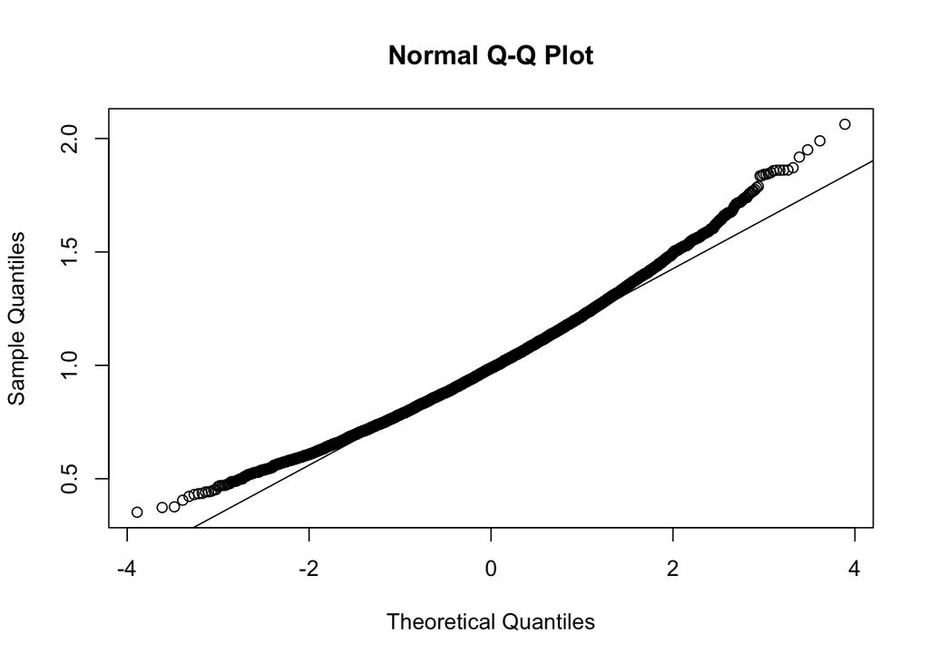

```r
qqnorm(sample_means)
qqline(sample_means)
```

A Q-Q plot from simulated data will almost never fall perfectly on the line.

The question is whether deviations from the line are sufficiently small and unsystematic that you are comfortable describing the distribution as approximately normal.

**Tip**

But you can also find the difference between the 2 lines.

qqnorm(sample_means) qqline(sample_means)

## 6.3 Numerical Evidence

Consider statistics such as:

- mean;
- standard deviation;
- skewness;
- kurtosis.

You may also investigate formal tests of normality.

**Warning**

Do not allow one test or one p-value to make the decision for you.

You are investigating **approximate normality**, not attempting to prove that simulated data come from a perfectly normal distribution.

# 7 Establish Your Own “Normal Enough” Standard

Before giving your final answers, clearly explain:

> **What does “approximately normal” mean in my analysis?**

Develop a reasonable standard and then apply it consistently.

Your standard should use graphical and/or numerical evidence.

You will be graded much more heavily on the quality of your **reasoning and evidence** than on whether your final (n) matches someone else’s.

Two students may reasonably select different values of (n).

That is okay.

What matters is whether you can defend your answer.

# 8 Random Seeds and Reproducibility

Your analysis must be reproducible.

Use the **last four digits of your student ID** as your random seed.

For example, if your student ID is `12345678`:

```r
student_id <- 5678

set.seed(student_id)
```

Set the seed immediately before each simulation experiment so that your results can be reproduced.

Do not repeatedly change your seed simply because you do not like the results.

## 8.1 Reproducibility Experiment

After completing one of your analyses, rerun it using a different seed.

Ask:

1. **Did the exact results change?**
2. **Did my scientific conclusion change?**

Explain what this tells you about Monte Carlo simulation and reproducibility.

# 9 R Skills

Your project should demonstrate appropriate use of R.

You are expected to become comfortable with functions and techniques including:

```r
replicate()
apply()

mean()
sd()

hist()

qqnorm()
qqline()
```

as well as the random-number-generation functions appropriate for your assigned populations.

You may use additional R functions and packages when they improve your analysis.

**Important**

You are responsible for understanding every line of code you submit.

If you cannot explain what a line of code does, you should not submit it as your work.

# 10 Required Analysis for Each Population

For every distribution, your analysis should clearly answer the following questions.

## 10.1 1. What population are you sampling from?

Describe its important characteristics.

## 10.2 2. What did you expect before running the simulation?

Make a prediction.

## 10.3 3. Which sample sizes did you investigate?

Explain how and why you selected them.

## 10.4 4. When did the sampling distribution become approximately normal?

Provide your final answer:

$$\boxed{n=\text{your answer}}$$

If you conclude that there is no reasonable value of (n), state that and defend it.

## 10.5 6. Why did you choose that value?

Support your decision using your histogram, Q-Q plot, and numerical evidence.

## 10.6 7. What surprised you?

Identify at least one feature of your actual simulation that you did not expect.

# 11 Final Cross-Distribution Analysis

After completing the individual simulations, step back and compare your results.

Create a summary table similar to:

| Population | Smallest (n) judged normal | Skewness at chosen (n) | Kurtosis | Key observation |
| --- | --- | --- | --- | --- |
| Normal |  |  |  |  |
| Uniform |  |  |  |  |
| Exponential |  |  |  |  |
| … |  |  |  |  |

Then answer the larger research questions.

## 11.1 Sample Size

Is there evidence for a universal rule such as (n=30)?

## 11.2 Population Shape

Which populations converged most quickly?

Which converged most slowly?

Why?

## 11.3 Assumptions

What happened when observations were dependent?

What happened when observations were not identically distributed?

What happened with extremely heavy tails?

# 12 Deliverables

Your project will be maintained in **Git/GitHub**.

Create a separate Quarto/Markdown analysis file for each assigned population or experiment.

Your repository should contain approximately **12 analysis files**

Each analysis should contain:

- R code;
- simulation results;
- appropriate plots;
- statistical diagnostics;
- interpretation;
- your selected (n);
- justification for your conclusion.

You should also include a final summary document that compares your results across all populations and states your overall conclusions about the CLT.

**TipThink Like a Portfolio Reviewer**

Your GitHub repository should tell a coherent story.

Someone who did not take this class should be able to understand:

- what you investigated;
- how you investigated it;
- what you discovered;
- why it matters.

# 13 Use of AI

You may use AI extensively on this project.

However:

> **AI is a tool—not the person conducting the analysis.**

AI can help you:

- understand R syntax;
- debug code;
- suggest statistical methods;
- explain concepts;
- improve graphs;
- challenge your reasoning;
- improve your written presentation.

You remain responsible for:

- deciding what to investigate;
- validating the code;
- interpreting your actual simulation results;
- deciding what “normal enough” means;
- selecting your final values of (n);
- defending your conclusions.

You should be able to explain every important piece of your project without relying on AI.

## 13.1 Submit Your AI Interaction

Include a record of the important prompts you used with AI.

I am particularly interested in **iteration**.

Show examples where:

1. you asked AI something;
2. examined the response;
3. identified a problem, weakness, or unanswered question;
4. improved your prompt;
5. obtained a better result.

Simply submitting:

> “Write my CLT project in R.”

is not evidence of effective AI use.

The interesting part is your **reasoning, validation, and re-prompting**.

# 14 How You Will Be Graded

This project is not primarily about whether your code runs.

You will be graded on whether you can **make and defend statistical conclusions using computational evidence**.

Strong projects will demonstrate:

- correct and reproducible R code;
- thoughtful experimental design;
- appropriate use of Monte Carlo simulation;
- effective graphical analysis;
- appropriate numerical/statistical analysis;
- understanding of normality;
- understanding of the Central Limit Theorem;
- recognition of CLT assumptions and limitations;
- evidence-based selection of (n);
- comparison across populations;
- effective use and validation of AI;
- clear communication;
- a professional GitHub repository.

**ImportantThe Interview Test**

If someone showed you one of your graphs six months from now, could you explain:

- what it means;
- why you created it;
- how it supports your conclusion?

If the answer is yes, you understand your project.

# 15 Portfolio / Resume Component

This project is designed to be suitable for your GitHub portfolio **if you complete it at a professional level**.

## 15.1 Suggested Project Title

**How Fast Does Normal Happen? Stress-Testing the Central Limit Theorem**

*An R-Based Monte Carlo Study of Sample Size, Population Shape, and Statistical Assumptions*

## 15.2 Alternative Formal Title

**Beyond the Bell Curve: Evaluating Central Limit Theorem Convergence**

*Monte Carlo Evidence Across Sample Sizes, Distributions, and Dependence Structures*

## 15.3 Possible Resume / GitHub Description

> Developed reproducible Monte Carlo simulations in R to measure how quickly sampling distributions approach normality across multiple population distributions and sample sizes. Evaluated convergence using Q-Q plots, skewness, kurtosis, and formal normality tests, then examined how dependence and heavy-tailed populations affect classical Central Limit Theorem results.

**Warning**

Do not put this description on your resume simply because you completed the assignment.

Put it there if you can **explain and defend what it means in an interview**.